# Lab4_AnaghaUppal

Anagha Uppal

4/24/2018

## QUESTION 1

Libraries

```r
library(regclass)
library(stats)
library(pracma)
library(itsmr)
```

Importing data

```r
setwd("~/Desktop/Anagha/UCSB/Classes/GEOG 210C/Lab4")
data1 <- read.table("ding-data1.txt", header=FALSE)
```

Plotting all variables together

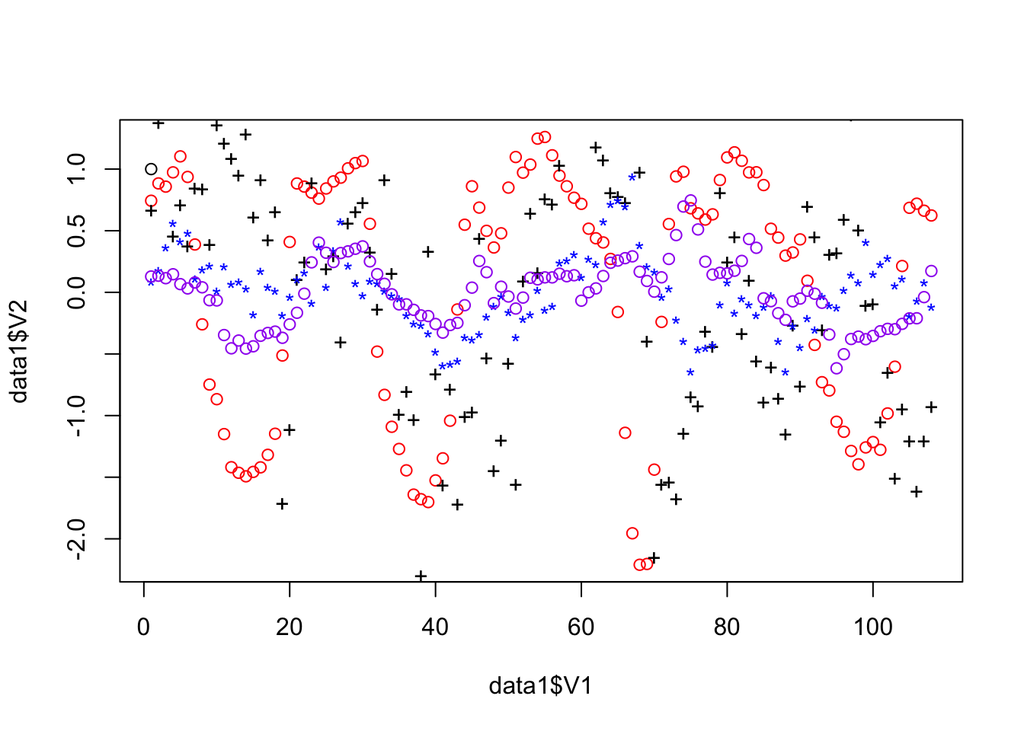

```r
plot(data1$V1,data1$V2, col="red")
points(data1$V1,data1$V3,pch="+")
points(data1$V1, data1$V4,pch="*",col="blue")
points(data1$V1, data1$V5, col="purple")
points(data1$V1)
```

Creating a linear regression model on everything and plotting the fitline over the data.

```r
linMod <- lm(V5~.-V1,data=data1)
summary(linMod)
```

```
##
## Call:
## lm(formula = V5 ~ . - V1, data = data1)
##
## Residuals:
##      Min       1Q   Median       3Q      Max
## -0.43203 -0.16407 -0.02736  0.13346  0.72455
##
## Coefficients:
##               Estimate Std. Error t value Pr(>|t|)
## (Intercept)  8.463e-07  2.054e-02   0.000   1.0000
## V2           1.581e-01  2.065e-02   7.653 1.05e-11 ***
## V3          -2.562e-03  2.426e-02  -0.106   0.9161
## V4           1.381e-01  7.920e-02   1.744   0.0842 .
## ---
## Signif. codes:  0 '***' 0.001 '**' 0.01 '*' 0.05 '.' 0.1 ' ' 1
##
## Residual standard error: 0.2134 on 104 degrees of freedom
## Multiple R-squared:  0.3685, Adjusted R-squared:  0.3503
## F-statistic: 20.23 on 3 and 104 DF,  p-value: 2.101e-10
```

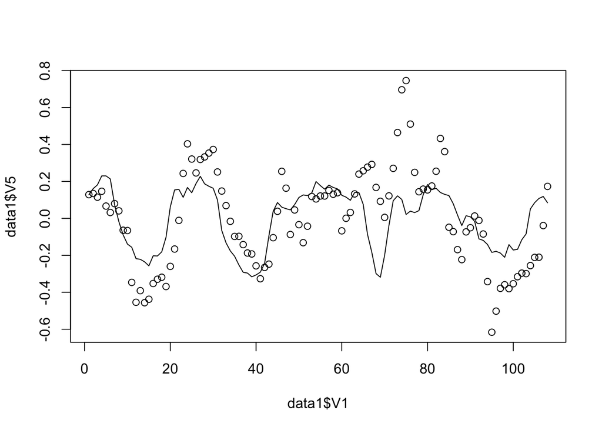

```r
plot(data1$V1,data1$V5)
(lines(predict(linMod)))
```

```r
sqrt(summary(linMod)$adj.r.squared) #this is the correlation coefficient
```

```
## [1] 0.5918648
```

```r
#0.59
```

Part 3 is also calculated here. The correlation between var4 and regressed var4 is 0.59. Var1 (Var2 in the table) is the only significant predictor and therefore, the most important one.

Data kernel method:

```r
M=3
P = length(data1$V1)
G = matrix(0,P,M)
G[,1] = data1$V2
G[,2] = data1$V3
G[,3] = data1$V4

GT = t(G)


mest = inv(GT%*%G)%*%(GT%*%data1$V5)
dpre = G%*%mest
e = data1$V5 - dpre
E = t(e)%*%e
```

## PART 2

# Importing new data

```r
data2 <- read.table("ding-data2.txt", header=FALSE)
```

Plotting X

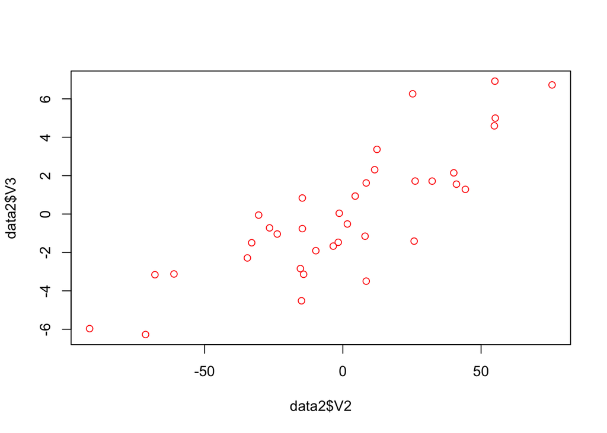

```r
plot(data2$V2,data2$V3, col="red")
```

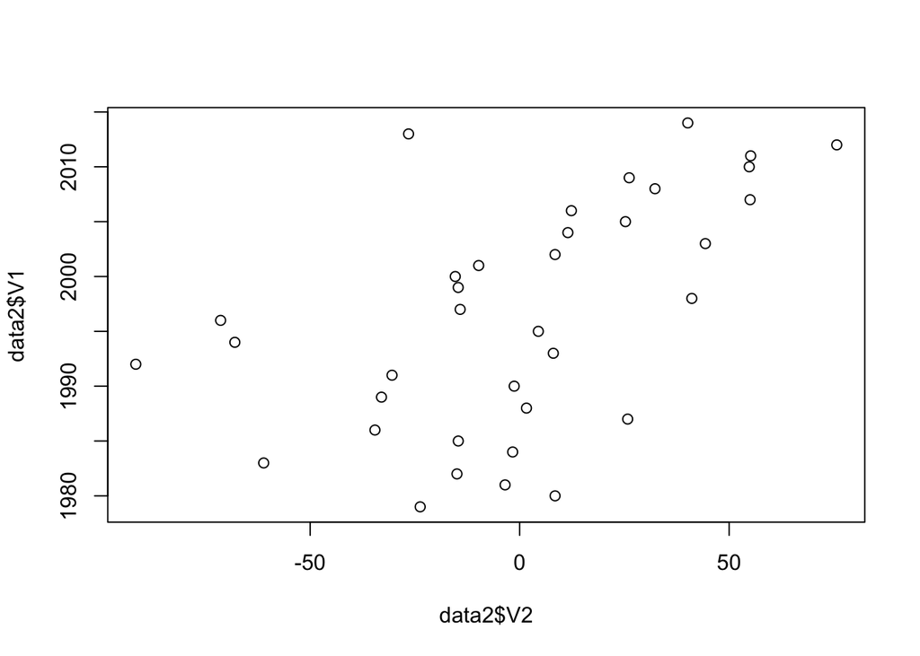

```r
plot(data2$V2,data2$V1)
```

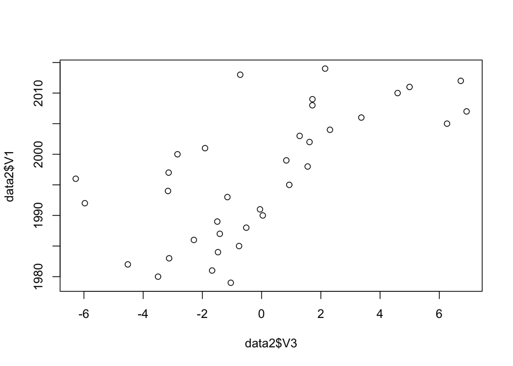

```r
plot(data2$V3,data2$V1)
```

Building a linear regression model and calculating linear trends of X and Y

```r
linMod2 <- lm(V3~V2,data = data2)
linMod2
```

```
##
## Call:
## lm(formula = V3 ~ V2, data = data2)
##
## Coefficients:
## (Intercept)           V2
##  -0.0000134    0.0713601
```

```r
summary(linMod2)
```

```
##
## Call:
## lm(formula = V3 ~ V2, data = data2)
##
## Residuals:
##     Min      1Q  Median      3Q     Max
## -4.0995 -1.3592  0.2314  1.1876  4.4607
##
## Coefficients:
##               Estimate Std. Error t value Pr(>|t|)
## (Intercept) -0.0000134  0.3140417   0.000        1
## V2           0.0713601  0.0083336   8.563 5.29e-10 ***
## ---
## Signif. codes:  0 '***' 0.001 '**' 0.01 '*' 0.05 '.' 0.1 ' ' 1
##
## Residual standard error: 1.884 on 34 degrees of freedom
## Multiple R-squared:  0.6832, Adjusted R-squared:  0.6739
## F-statistic: 73.32 on 1 and 34 DF,  p-value: 5.292e-10
```

```r
sqrt(summary(linMod2)$adj.r.squared) #this is the correlation coefficient
```

```
## [1] 0.8209036
```

```r
#0.8209
linModX <- lm(V2~V1,data=data2)
linModY <- lm(V3~V1,data=data2)
```

Residuals from X and Y and plotting, and finally calculating correlation between two residual time series

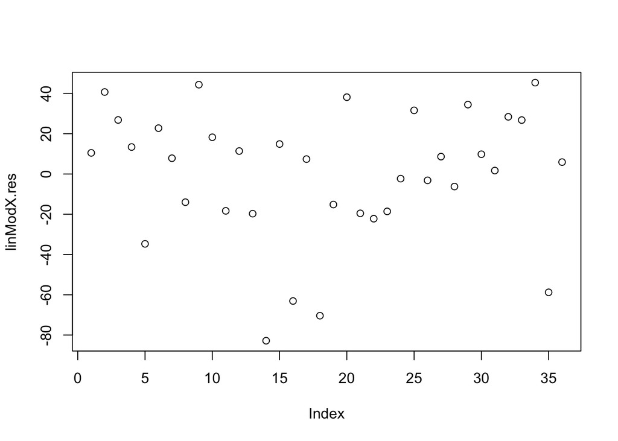

```r
linModX.res = resid(linModX)
linModY.res = resid(linModY)
plot(linModX.res)
```

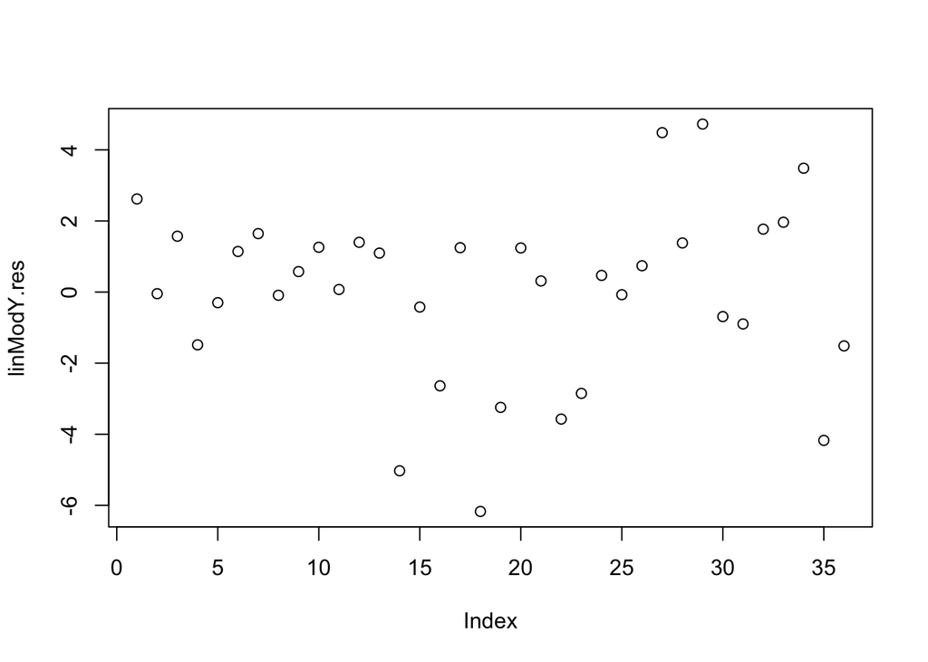

```r
plot(linModY.res)
```

```r
linMod2.1 <- lm(linModY.res~linModX.res,data=data2)
summary(linMod2.1)
```

```
##
## Call:
## lm(formula = linModY.res ~ linModX.res, data = data2)
##
## Residuals:
##     Min      1Q  Median      3Q     Max
## -2.3822 -1.3991  0.1909  0.9865  3.9948
##
## Coefficients:
##               Estimate Std. Error t value Pr(>|t|)
## (Intercept) -2.557e-16  2.774e-01   0.000        1
## linModX.res  5.678e-02  8.740e-03   6.497 1.96e-07 ***
## ---
## Signif. codes:  0 '***' 0.001 '**' 0.01 '*' 0.05 '.' 0.1 ' ' 1
##
## Residual standard error: 1.664 on 34 degrees of freedom
## Multiple R-squared:  0.5539, Adjusted R-squared:  0.5407
## F-statistic: 42.21 on 1 and 34 DF,  p-value: 1.964e-07
```

```r
sqrt(summary(linMod2.1)$adj.r.squared) #this is the correlation coefficient
```

```
## [1] 0.7353459
```

```r
#In this case, the correlation coefficient is 0.7353
```

Regressed quadratic model

```r
quadModX <- lm(data2$V2~poly(data2$V1,2, raw=FALSE))
quadModY <- lm(data2$V3~poly(data2$V1,2, raw=FALSE))
quadModX.res = resid(quadModX)
quadModY.res = resid(quadModY)
quadMod3 <- lm(quadModY.res~poly(quadModX.res,2,raw=TRUE))
summary(quadMod3)
```

```
##
## Call:
## lm(formula = quadModY.res ~ poly(quadModX.res, 2, raw = TRUE))
##
## Residuals:
##     Min      1Q  Median      3Q     Max
## -2.6767 -1.3115  0.3201  1.0140  3.8691
##
## Coefficients:
##                                      Estimate Std. Error t value Pr(>|t|)
## (Intercept)                         0.2501727  0.3457814   0.723    0.474
## poly(quadModX.res, 2, raw = TRUE)1  0.0496561  0.0110452   4.496 8.08e-05
## poly(quadModX.res, 2, raw = TRUE)2 -0.0002778  0.0002319  -1.198    0.239
##
## (Intercept)
## poly(quadModX.res, 2, raw = TRUE)1 ***
## poly(quadModX.res, 2, raw = TRUE)2
## ---
## Signif. codes:  0 '***' 0.001 '**' 0.01 '*' 0.05 '.' 0.1 ' ' 1
##
## Residual standard error: 1.654 on 33 degrees of freedom
## Multiple R-squared:  0.5477, Adjusted R-squared:  0.5203
## F-statistic: 19.98 on 2 and 33 DF,  p-value: 2.064e-06
```

```r
sqrt(summary(quadMod3)$adj.r.squared) #this is the correlation coefficient
```

```
## [1] 0.7213018
```

## QUESTION 3

Part 1: Sum of first 10 sine terms to make square wave using individual components of waves.

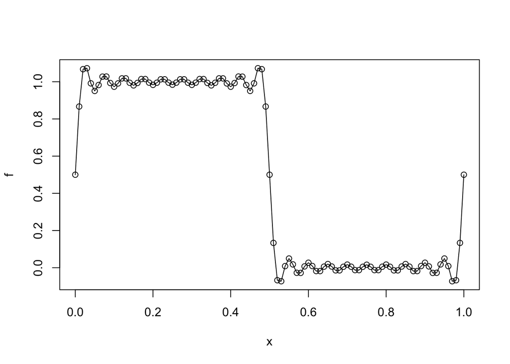

```r
N = 20;
x = c(0:100)/100;
f = ones(1,101)*1/2;
ff= zeros(1,101);
for (i in seq(1,N,2)) {
      a = 2/pi/i;
      f = f+a*sin(2*pi*i*x);
}

plot(x,f)
lines(x,f)
```

The two bits different for this part is that we want first 100 sin terms, so we’ll change N to 200. Additionally, we want 5 full periods and not 1, so we’ll add 5 to the f equation.

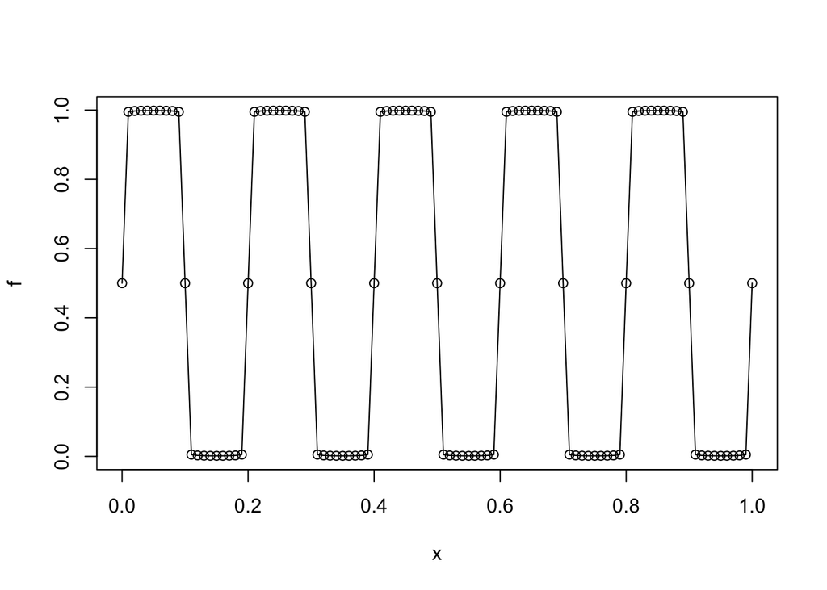

```r
N = 200;
x = c(0:100)/100;
f = ones(1,101)*1/2;
ff= zeros(1,101);
for (i in seq(1,N,2)) {
      a = 2/pi/i;
      f = f+a*sin(2*pi*5*i*x);
}

plot(x,f)
lines(x,f)
```